# Segmentation

**Made By DAHOU RENAUD L. Data Scientist in Benin**

- Whatsapp: +22967927952
- Email: dahou.r@yahoo.com

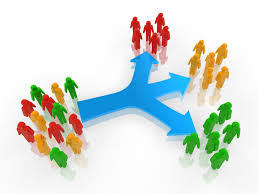

### pour déterminer qui sont nos meilleurs clients, l’ancien principe de matrice RFM est le meilleur. RFM signifie Recency, Frequency, and Monetary. Il s'agit d'une technique de segmentation de la clientèle qui utilise le comportement d'achat passé pour diviser les clients en groupes. [lien de la base de donnée](https://archive.ics.uci.edu/ml/datasets/online+retail)

Étape 1: Calculez les mesures RFM pour chaque client.

Étape 2: Ajoutez les numéros de segment à la table RFM.

Étape 3: Triez selon les scores RFM des meilleurs clients (score 111).

Étape 4: Construction de grappe et visualisation.

## Conexion à notre répertoire

```python
from google.colab import drive
drive.mount('/content/drive/')
```

```python
import os
os.chdir("/content/drive/My Drive/DATASCIENCE/Projet/Segmentation_de_client")
```

```python
#!jupyter nbconvert --to html Segmentation.ipynb
```

[output not shown]

### Télechargement de la base de donnée

```python
# download dataset
#! wget https://archive.ics.uci.edu/ml/machine-learning-databases/00352/Online%20Retail.xlsx -P "/content/drive/My Drive/DATASCIENCE/Projet/prédiction_de_prix_des_maison"
```

```python
#load dataset
import pandas as pd
import warnings
warnings.filterwarnings('ignore')
df = pd.read_excel("/content/drive/My Drive/DATASCIENCE/Projet/Segmentation_de_client/Online Retail.xlsx")
df = pd.read_csv(path, header=None, names=col_names)
```

```python
df1 = df
df1.head()
```

|  | InvoiceNo | StockCode | Description | Quantity | InvoiceDate | UnitPrice | CustomerID | Country |
| --- | --- | --- | --- | --- | --- | --- | --- | --- |
| 0 | 536365 | 85123A | WHITE HANGING HEART T-LIGHT HOLDER | 6 | 2010-12-01 08:26:00 | 2.55 | 17850.0 | United Kingdom |
| 1 | 536365 | 71053 | WHITE METAL LANTERN | 6 | 2010-12-01 08:26:00 | 3.39 | 17850.0 | United Kingdom |
| 2 | 536365 | 84406B | CREAM CUPID HEARTS COAT HANGER | 8 | 2010-12-01 08:26:00 | 2.75 | 17850.0 | United Kingdom |
| 3 | 536365 | 84029G | KNITTED UNION FLAG HOT WATER BOTTLE | 6 | 2010-12-01 08:26:00 | 3.39 | 17850.0 | United Kingdom |
| 4 | 536365 | 84029E | RED WOOLLY HOTTIE WHITE HEART. | 6 | 2010-12-01 08:26:00 | 3.39 | 17850.0 | United Kingdom |

L'ensemble de données contient toutes les transactions entre le 01/12/2010 et le 09/12/2011 pour un détaillant en ligne basé au Royaume-Uni et enregistré.

Explorez les données - validation et nouvelles variables

1. Valeurs manquantes dans les colonnes importantes;
2. distribution des clients dans chaque pays;
3. Le prix unitaire et la quantité doivent être> 0;
4. La date de facturation devrait <aujourd'hui.

```python
#Il y avait 38 pays uniques comme suit:
df1.Country.nunique()
df1.Country.unique()
```

```
array(['United Kingdom', 'France', 'Australia', 'Netherlands', 'Germany',
       'Norway', 'EIRE', 'Switzerland', 'Spain', 'Poland', 'Portugal',
       'Italy', 'Belgium', 'Lithuania', 'Japan', 'Iceland',
       'Channel Islands', 'Denmark', 'Cyprus', 'Sweden', 'Austria',
       'Israel', 'Finland', 'Bahrain', 'Greece', 'Hong Kong', 'Singapore',
       'Lebanon', 'United Arab Emirates', 'Saudi Arabia',
       'Czech Republic', 'Canada', 'Unspecified', 'Brazil', 'USA',
       'European Community', 'Malta', 'RSA'], dtype=object)
```

```python
customer_country=df1[['Country','CustomerID']].drop_duplicates()
customer_country.groupby(['Country'])['CustomerID'].aggregate('count').reset_index().sort_values('CustomerID', ascending=False)
```

|  | Country | CustomerID |
| --- | --- | --- |
| 36 | United Kingdom | 3950 |
| 14 | Germany | 95 |
| 13 | France | 87 |
| 31 | Spain | 31 |
| 3 | Belgium | 25 |
| 33 | Switzerland | 21 |
| 27 | Portugal | 19 |
| 19 | Italy | 15 |
| 12 | Finland | 12 |
| 1 | Austria | 11 |
| 25 | Norway | 10 |
| 24 | Netherlands | 9 |
| 0 | Australia | 9 |
| 6 | Channel Islands | 9 |
| 9 | Denmark | 9 |
| 7 | Cyprus | 8 |
| 32 | Sweden | 8 |
| 20 | Japan | 8 |
| 26 | Poland | 6 |
| 34 | USA | 4 |
| 5 | Canada | 4 |
| 37 | Unspecified | 4 |
| 18 | Israel | 4 |
| 15 | Greece | 4 |
| 10 | EIRE | 3 |
| 23 | Malta | 2 |
| 35 | United Arab Emirates | 2 |
| 2 | Bahrain | 2 |
| 22 | Lithuania | 1 |
| 8 | Czech Republic | 1 |
| 21 | Lebanon | 1 |
| 28 | RSA | 1 |
| 29 | Saudi Arabia | 1 |
| 30 | Singapore | 1 |
| 17 | Iceland | 1 |
| 4 | Brazil | 1 |
| 11 | European Community | 1 |
| 16 | Hong Kong | 0 |

Plus de 90% des clients dans les données proviennent du Royaume-Uni. Certaines recherches indiquent que les groupes de clients varient selon les régions. Je limiterai donc les données au Royaume-Uni.

```python
df1 = df1.loc[df1['Country'] == 'United Kingdom']

#Vérifions s'il y a des valeurs manquantes dans chaque colonne
df1.isnull().sum(axis=0)
```

```
InvoiceNo           0
StockCode           0
Description      1454
Quantity            0
InvoiceDate         0
UnitPrice           0
CustomerID     133600
Country             0
dtype: int64
```

Il y a 133 600 valeurs manquantes dans la colonne CustomerID et, comme notre analyse est basée sur les clients, nous allons supprimer ces valeurs manquantes.

```python
df1 = df1[pd.notnull(df1['CustomerID'])]
```

```python
#Vérifions les valeurs minimales dans les colonnes UnitPrice et Quantity.
df1.UnitPrice.min()
```

```
0.0
```

```python
df1.Quantity.min()
```

```
-80995
```

```python
#Supprimons les valeurs négatives dans la colonne Quantity.

df1 = df1[(df1['Quantity']>0)]
df1.shape
```

```
(354345, 8)
```

```python
df1.info()
```

```
<class 'pandas.core.frame.DataFrame'>
Int64Index: 354345 entries, 0 to 541893
Data columns (total 8 columns):
InvoiceNo      354345 non-null object
StockCode      354345 non-null object
Description    354345 non-null object
Quantity       354345 non-null int64
InvoiceDate    354345 non-null datetime64[ns]
UnitPrice      354345 non-null float64
CustomerID     354345 non-null float64
Country        354345 non-null object
dtypes: datetime64[ns](1), float64(2), int64(1), object(4)
memory usage: 24.3+ MB
```

```python
#Après avoir nettoyé les données, nous avons maintenant 354345 lignes et 8 colonnes.
#Vérifions la valeur unique pour chaque colonne.

def unique_counts(df1):
   for i in df1.columns:
       count = df1[i].nunique()
       print(i, ": ", count)
unique_counts(df1)
```

```
InvoiceNo :  16649
StockCode :  3645
Description :  3844
Quantity :  294
InvoiceDate :  15615
UnitPrice :  403
CustomerID :  3921
Country :  1
```

```python
# ajoutons une collone TotalPrice
df1['TotalPrice'] = df1['Quantity'] * df1['UnitPrice']
```

```python
#Découvrons les dates de première et dernière commande dans les données.
df1['InvoiceDate'].min()
```

```
Timestamp('2010-12-01 08:26:00')
```

```python
df1['InvoiceDate'].max()
```

```
Timestamp('2011-12-09 12:49:00')
```

Étant donné que la récence (recency) est calculée pour un moment donné et que la dernière date de facturation est 2011-12-09, nous utiliserons 2011-12-10 pour la calculer

```python
import datetime as dt
NOW = dt.datetime(2011,12,10)
df1['InvoiceDate'] = pd.to_datetime(df1['InvoiceDate'])
```

## Segmentation client RFM

La segmentation RFM commence à partir d'ici.

Créons une table RFM et calculons des métriques RFM pour chaque client

```python
rfmTable = df1.groupby('CustomerID').agg({'InvoiceDate': lambda x: (NOW - x.max()).days,
                                        'InvoiceNo': lambda x: len(x),
                                        'TotalPrice': lambda x: x.sum()})

rfmTable['InvoiceDate'] = rfmTable['InvoiceDate'].astype(int)
rfmTable.rename(columns={'InvoiceDate': 'recency',
                         'InvoiceNo': 'frequency',
                         'TotalPrice': 'monetary_value'}, inplace=True)
rfmTable.head()
```

| CustomerID | recency | frequency | monetary_value |
| --- | --- | --- | --- |
| 12346.0 | 325 | 1 | 77183.60 |
| 12747.0 | 2 | 103 | 4196.01 |
| 12748.0 | 0 | 4596 | 33719.73 |
| 12749.0 | 3 | 199 | 4090.88 |
| 12820.0 | 3 | 59 | 942.34 |

### Interprétation:

1. CustomerID 12346 a une fréquence de 1, une valeur monétaire: 77 183,60 $ et une récence: 325 jours.
2. Le numéro d’identité client 12747 a une fréquence de 103, une valeur monétaire de 4 196,01 USD et une récence: 2 jours

```python
#Vérifions les détails du premier client.
first_customer = df1[df1['CustomerID']== 12346.0]
first_customer
```

|  | InvoiceNo | StockCode | Description | Quantity | InvoiceDate | UnitPrice | CustomerID | Country | TotalPrice |
| --- | --- | --- | --- | --- | --- | --- | --- | --- | --- |
| 61619 | 541431 | 23166 | MEDIUM CERAMIC TOP STORAGE JAR | 74215 | 2011-01-18 10:01:00 | 1.04 | 12346.0 | United Kingdom | 77183.6 |

Le premier client n'a acheté qu'une fois, a acheté un produit en grande quantité (74 215). Le prix unitaire est très bas; peut-être une vente de liquidation.

### Scinder les métriques

Le moyen le plus simple de scinder les métriques en segments consiste à utiliser des quartiles.

- Cela nous donne un point de départ pour l'analyse détaillée.
- 4 segments sont faciles à comprendre et à expliquer.

```python
quantiles = rfmTable.quantile(q=[0.25,0.5,0.75])
quantiles = quantiles.to_dict()
```

### Création d' une table RFM segmentée

```python
segmented_rfm = rfmTable
```

La plus récente récence, la fréquence la plus élevée et les montants monétaires sont nos meilleurs clients.

```python
def RScore(x,p,d):
    if x <= d[p][0.25]:
        return 1
    elif x <= d[p][0.50]:
        return 2
    elif x <= d[p][0.75]:
        return 3
    else:
        return 4

def FMScore(x,p,d):
    if x <= d[p][0.25]:
        return 4
    elif x <= d[p][0.50]:
        return 3
    elif x <= d[p][0.75]:
        return 2
    else:
        return 1
```

```python
#Ajoutons des numéros de segment à la table RFM segmentée nouvellement créée
segmented_rfm['r_quartile'] = segmented_rfm['recency'].apply(RScore, args=('recency',quantiles,))
segmented_rfm['f_quartile'] = segmented_rfm['frequency'].apply(FMScore, args=('frequency',quantiles,))
segmented_rfm['m_quartile'] = segmented_rfm['monetary_value'].apply(FMScore, args=('monetary_value',quantiles,))
segmented_rfm.head()
```

| CustomerID | recency | frequency | monetary_value | r_quartile | f_quartile | m_quartile |
| --- | --- | --- | --- | --- | --- | --- |
| 12346.0 | 325 | 1 | 77183.60 | 4 | 4 | 1 |
| 12747.0 | 2 | 103 | 4196.01 | 1 | 1 | 1 |
| 12748.0 | 0 | 4596 | 33719.73 | 1 | 1 | 1 |
| 12749.0 | 3 | 199 | 4090.88 | 1 | 1 | 1 |
| 12820.0 | 3 | 59 | 942.34 | 1 | 2 | 2 |

Les segments RFM divisent la clientèle en un cube 3D imaginaire difficile à visualiser. Cependant, nous pouvons résoudre ce problème.

### Ajoutons une nouvelle colonne pour combiner le score RFM: 111 est le score le plus élevé déterminé précédemment

```python
segmented_rfm['RFMScore'] = segmented_rfm.r_quartile.map(str)+ segmented_rfm.f_quartile.map(str)+ segmented_rfm.m_quartile.map(str)
segmented_rfm.head()
```

| CustomerID | recency | frequency | monetary_value | r_quartile | f_quartile | m_quartile | RFMScore |
| --- | --- | --- | --- | --- | --- | --- | --- |
| 12346.0 | 325 | 1 | 77183.60 | 4 | 4 | 1 | 441 |
| 12747.0 | 2 | 103 | 4196.01 | 1 | 1 | 1 | 111 |
| 12748.0 | 0 | 4596 | 33719.73 | 1 | 1 | 1 | 111 |
| 12749.0 | 3 | 199 | 4090.88 | 1 | 1 | 1 | 111 |
| 12820.0 | 3 | 59 | 942.34 | 1 | 2 | 2 | 122 |

Il est évident que le premier client n'est pas notre meilleur client.

### Qui sont le top 10 de nos meilleurs clients!

```python
segmented_rfm[segmented_rfm['RFMScore']=='111'].sort_values('monetary_value', ascending=False).head(10)
```

| CustomerID | recency | frequency | monetary_value | r_quartile | f_quartile | m_quartile | RFMScore |
| --- | --- | --- | --- | --- | --- | --- | --- |
| 18102.0 | 0 | 431 | 259657.30 | 1 | 1 | 1 | 111 |
| 17450.0 | 8 | 337 | 194550.79 | 1 | 1 | 1 | 111 |
| 17511.0 | 2 | 963 | 91062.38 | 1 | 1 | 1 | 111 |
| 16684.0 | 4 | 277 | 66653.56 | 1 | 1 | 1 | 111 |
| 14096.0 | 4 | 5111 | 65164.79 | 1 | 1 | 1 | 111 |
| 13694.0 | 3 | 568 | 65039.62 | 1 | 1 | 1 | 111 |
| 15311.0 | 0 | 2379 | 60767.90 | 1 | 1 | 1 | 111 |
| 13089.0 | 2 | 1818 | 58825.83 | 1 | 1 | 1 | 111 |
| 15769.0 | 7 | 130 | 56252.72 | 1 | 1 | 1 | 111 |
| 15061.0 | 3 | 403 | 54534.14 | 1 | 1 | 1 | 111 |

### **Cindage en grappe et Visualisation**

```python
x=segmented_rfm.loc[:,['RFMScore']].values
```

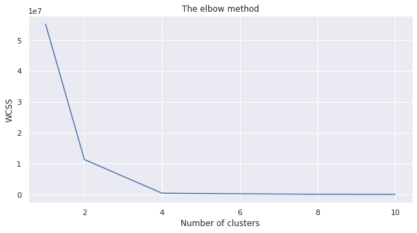

```python
rcParams['figure.figsize'] = 10,5
#Finding the optimum number of clusters for k-means classification
from sklearn.cluster import KMeans
wcss = []

for i in range(1, 11):
    kmeans = KMeans(n_clusters = i, init = 'k-means++', max_iter = 300, n_init = 10, random_state = 0)
    kmeans.fit(x)
    wcss.append(kmeans.inertia_)

#Plotting the results onto a line graph, allowing us to observe 'The elbow'
plt.plot(range(1, 11), wcss)
plt.title('The elbow method')
plt.xlabel('Number of clusters')
plt.ylabel('WCSS') #within cluster sum of squares
plt.show()
```

Notre graphique nous indique que le nombre de grappe serait 4 ainsi donc nous aurons 4 catégories de client

```python
kmeans = KMeans(n_clusters=4)
df=segmented_rfm
df['label'] = kmeans.fit_predict(df[['RFMScore']])
df["RFMScore"] = pd.to_numeric(df["RFMScore"])
df
```

| CustomerID | recency | frequency | monetary_value | r_quartile | f_quartile | m_quartile | RFMScore | label |
| --- | --- | --- | --- | --- | --- | --- | --- | --- |
| 12346.0 | 325 | 1 | 77183.60 | 4 | 4 | 1 | 441 | 2 |
| 12747.0 | 2 | 103 | 4196.01 | 1 | 1 | 1 | 111 | 1 |
| 12748.0 | 0 | 4596 | 33719.73 | 1 | 1 | 1 | 111 | 1 |
| 12749.0 | 3 | 199 | 4090.88 | 1 | 1 | 1 | 111 | 1 |
| 12820.0 | 3 | 59 | 942.34 | 1 | 2 | 2 | 122 | 1 |
| ... | ... | ... | ... | ... | ... | ... | ... | ... |
| 18280.0 | 277 | 10 | 180.60 | 4 | 4 | 4 | 444 | 2 |
| 18281.0 | 180 | 7 | 80.82 | 4 | 4 | 4 | 444 | 2 |
| 18282.0 | 7 | 12 | 178.05 | 1 | 4 | 4 | 144 | 1 |
| 18283.0 | 3 | 756 | 2094.88 | 1 | 1 | 1 | 111 | 1 |
| 18287.0 | 42 | 70 | 1837.28 | 2 | 2 | 1 | 221 | 3 |

3921 rows × 8 columns

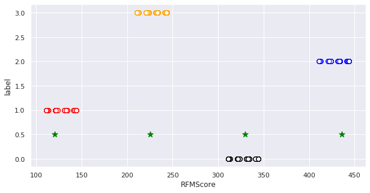

```python
ax = df[df['label']==0].plot.scatter(x='RFMScore', y='label', s=50, color='white', edgecolor='black')

df[df['label']==1].plot.scatter(x='RFMScore', y='label', s=50, color='white', ax=ax, edgecolor='red')
df[df['label']==2].plot.scatter(x='RFMScore', y='label', s=50, color='white', ax=ax, edgecolor='blue')
df[df['label']==3].plot.scatter(x='RFMScore', y='label', s=50, color='white', ax=ax, edgecolor='Orange')

plt.scatter(kmeans.cluster_centers_.ravel(), [0.5]*len(kmeans.cluster_centers_), s=100, color='green', marker='*')
```

Comme on peut le voir nos clients sont groupés en fonction de leurs scores RFM. nous avons respectivement des score RFM compris entre [100, 200, 300, 400, 450].Renommons ces intervalles par VIP, HVC, MVC, MME pour désigner nos classes de client

```python
df['class']=pd.cut(df.RFMScore, bins=[100, 200, 300, 400, 450], labels=['VIP', 'HVC', 'MVC', 'MM'])
df
```

| CustomerID | recency | frequency | monetary_value | r_quartile | f_quartile | m_quartile | RFMScore | label | class |
| --- | --- | --- | --- | --- | --- | --- | --- | --- | --- |
| 12346.0 | 325 | 1 | 77183.60 | 4 | 4 | 1 | 441 | 2 | MM |
| 12747.0 | 2 | 103 | 4196.01 | 1 | 1 | 1 | 111 | 1 | VIP |
| 12748.0 | 0 | 4596 | 33719.73 | 1 | 1 | 1 | 111 | 1 | VIP |
| 12749.0 | 3 | 199 | 4090.88 | 1 | 1 | 1 | 111 | 1 | VIP |
| 12820.0 | 3 | 59 | 942.34 | 1 | 2 | 2 | 122 | 1 | VIP |
| ... | ... | ... | ... | ... | ... | ... | ... | ... | ... |
| 18280.0 | 277 | 10 | 180.60 | 4 | 4 | 4 | 444 | 2 | MM |
| 18281.0 | 180 | 7 | 80.82 | 4 | 4 | 4 | 444 | 2 | MM |
| 18282.0 | 7 | 12 | 178.05 | 1 | 4 | 4 | 144 | 1 | VIP |
| 18283.0 | 3 | 756 | 2094.88 | 1 | 1 | 1 | 111 | 1 | VIP |
| 18287.0 | 42 | 70 | 1837.28 | 2 | 2 | 1 | 221 | 3 | HVC |

3921 rows × 9 columns

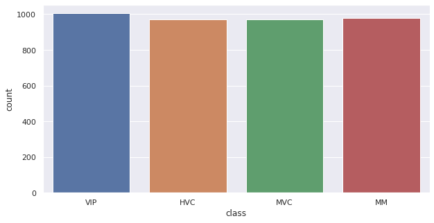

```python
#create count plot for room types
import seaborn as sns
%matplotlib inline
from matplotlib import rcParams
# figure size in inches
rcParams['figure.figsize'] = 10,5
sns.set(style="darkgrid")
ax = sns.countplot(x='class', data=df)
plt.show()
```